# JTF003-EC: Measurement invariance visualizations (visualizemi)

2026-11-25

This document mirrors the multi-group CFAs in `results.qmd` (“Scales reliability and measurement invariance”) and adds the `visualizemi` tools: `mgcfa()` (stepwise invariance models plus tidy coefficients), `plot_mi()` (item-level visualization of intercepts, latent means, and variances/residuals for **two groups at a time**), and `partial_mi()` (which single constraints, if freed, improve fit).

## Data

Data preparation and exclusions are reused from `results.qmd` (chunks `load_data`, `apply_exclusions`, `data_preparation`, `data_preparation_2`) so the sample is identical to the report.

````r
prep_labels <- c("load_data", "apply_exclusions", "data_preparation", "data_preparation_2")
qmd <- readLines("results.qmd", warn = FALSE)
get_chunk <- function(lab) {
  st <- grep(paste0("^```\\{r ", lab, "[,}]"), qmd)[1]
  en <- st + which(qmd[(st + 1):length(qmd)] == "```")[1]
  qmd[(st + 1):(en - 1)]
}
for (lab in prep_labels) {
  code <- get_chunk(lab)
  # country recoding only: skip the World Bank GDP / GCI joins (not needed for MI)
  if (lab == "data_preparation") code <- c(code[seq_len(grep("^wb_iso2_alias", code) - 1)],
              code[(grep("mutate\\(culture", code) - 1):(grep("^gci <- read.csv", code) - 1)])
  # long-format reshaping starts at d_crt_long; not needed here
  if (lab == "data_preparation_2") code <- code[seq_len(grep("^d_crt_long", code)[1] - 1)]
  eval(parse(text = code), envir = globalenv())
}

IH_items  <- paste0("IH_", 1:9)
AOT_items <- paste0("AOT_", 1:13)
IC_items  <- paste0("IC_", 1:16)
````

## Models (same specifications as `results.qmd`)

```r
IH_model <- '
  IH =~ IH_1 + IH_2 + IH_3 + IH_4 + IH_5 + IH_6 + IH_7 + IH_8 + IH_9
  POS =~ IH_1 + IH_2 + IH_3 + IH_4 + IH_5 + IH_7
  NEG =~ IH_6 + IH_8 + IH_9
  IH ~~ 0*POS
  IH ~~ 0*NEG
  POS ~~ NEG
  POS ~~ 1*POS
  NEG ~~ 1*NEG'
IH_method <- c(paste0("POS=~", c("IH_1","IH_2","IH_3","IH_4","IH_5","IH_7")),
               paste0("NEG=~", c("IH_6","IH_8","IH_9")))

AOT_model <- '
  AOT =~ AOT_1 + AOT_2 + AOT_3 + AOT_4 + AOT_5 + AOT_6 + AOT_7 +
         AOT_8 + AOT_9 + AOT_10 + AOT_11 + AOT_12 + AOT_13
  NEG =~ AOT_2 + AOT_4 + AOT_5 + AOT_6 + AOT_7 + AOT_8 + AOT_10 + AOT_13
  AOT ~~ 0*NEG
  NEG ~~ 1*NEG'
AOT_method <- paste0("NEG=~", paste0("AOT_", c(2,4,5,6,7,8,10,13)))

IC_model <- '
  HI =~ IC_1 + IC_2 + IC_3 + IC_4
  VI =~ IC_5 + IC_6 + IC_7 + IC_8
  HC =~ IC_9 + IC_10 + IC_11 + IC_12
  VC =~ IC_13 + IC_14 + IC_15 + IC_16'
```

## Choosing the country pair

`plot_mi()` compares two groups at a time. By default this uses the two countries with the most participants that meet each scale’s threshold (100 for IH/AOT, 200 for IC). Change `pairs` to compare any other pair.

```r
top_countries <- function(n_min, k = 2) {
  d %>% count(Country, sort = TRUE) %>% filter(n >= n_min) %>% slice_head(n = k) %>% pull(Country)
}
pairs <- list(IH = top_countries(100), AOT = top_countries(100), IC = top_countries(200))
pairs
```

```
## $IH
## [1] "United States" "Turkey"
##
## $AOT
## [1] "United States" "Turkey"
##
## $IC
## [1] "United States" "Turkey"
```

## Fit the stepwise multi-group models

`mgcfa()` fits configural, then metric (loadings), then scalar (intercepts). For IH and AOT the wording-factor loadings stay free (`group.partial`), as in the report.

```r
fit_pair <- function(model, items, countries, partial = NULL) {
  dat <- d %>% filter(Country %in% countries) %>% select(Country, all_of(items)) %>% as.data.frame()
  dat$Country <- as.character(dat$Country)
  mgcfa(model = model, data = dat, group = "Country",
        group.equal = c("loadings", "intercepts"),
        group.partial = partial,
        estimator = "MLR", std.lv = TRUE, meanstructure = TRUE,
        conf.level = .95)
}
mg_IH  <- fit_pair(IH_model,  IH_items,  pairs$IH,  IH_method)
mg_AOT <- fit_pair(AOT_model, AOT_items, pairs$AOT, AOT_method)
mg_IC  <- fit_pair(IC_model,  IC_items,  pairs$IC)

# step labels accepted by plot_mi(model_step = )
unique(mg_IC$model_coef$model)
```

```
## [1] "Overall"             "Group United States" "Group Turkey"
## [4] "Configural"          "loadings"            "intercepts"
```

```r
knitr::kable(mg_IH$model_fit,  digits = 3, caption = "IH: model fit by step")
```

IH: model fit by step

| agfi | AIC | BIC | cfi | chisq | npar | rmsea | rmsea.conf.high | srmr | tli | converged | estimator | ngroups | missing_method | nobs | norig | nexcluded | model |
| --- | --- | --- | --- | --- | --- | --- | --- | --- | --- | --- | --- | --- | --- | --- | --- | --- | --- |
| 0.998 | 93123.99 | 93347.40 | 0.972 | 138.269 | 37 | 0.048 | 0.056 | 0.021 | 0.940 | TRUE | ML | 1 | listwise | 3097 | 3097 | 0 | Overall |
| 0.998 | 48317.88 | 48518.19 | 0.974 | 73.625 | 37 | 0.045 | 0.056 | 0.021 | 0.944 | TRUE | ML | 1 | listwise | 1659 | 1659 | 0 | Group United States |
| 0.998 | 43951.05 | 44146.08 | 0.982 | 56.518 | 37 | 0.040 | 0.052 | 0.019 | 0.963 | TRUE | ML | 1 | listwise | 1438 | 1438 | 0 | Group Turkey |
| 0.998 | 92268.93 | 92715.76 | 0.978 | 130.143 | 74 | 0.043 | 0.051 | 0.020 | 0.954 | TRUE | ML | 2 | listwise | 3097 | 3097 | 0 | Configural |
| 0.998 | 92271.96 | 92670.48 | 0.976 | 149.170 | 66 | 0.041 | 0.048 | 0.025 | 0.958 | TRUE | ML | 2 | listwise | 3097 | 3097 | 0 | loadings |
| 0.996 | 92428.67 | 92790.96 | 0.938 | 317.883 | 60 | 0.060 | 0.067 | 0.036 | 0.908 | TRUE | ML | 2 | listwise | 3097 | 3097 | 0 | intercepts |

```r
knitr::kable(mg_AOT$model_fit, digits = 3, caption = "AOT: model fit by step")
```

AOT: model fit by step

| agfi | AIC | BIC | cfi | chisq | npar | rmsea | rmsea.conf.high | srmr | tli | converged | estimator | ngroups | missing_method | nobs | norig | nexcluded | model |
| --- | --- | --- | --- | --- | --- | --- | --- | --- | --- | --- | --- | --- | --- | --- | --- | --- | --- |
| 0.994 | 124821.63 | 125105.43 | 0.875 | 726.119 | 47 | 0.062 | 0.066 | 0.039 | 0.829 | TRUE | ML | 1 | listwise | 3097 | 3097 | 0 | Overall |
| 0.997 | 62599.49 | 62853.94 | 0.948 | 225.254 | 47 | 0.042 | 0.048 | 0.028 | 0.928 | TRUE | ML | 1 | listwise | 1659 | 1659 | 0 | Group United States |
| 0.994 | 60373.05 | 60620.79 | 0.871 | 362.258 | 47 | 0.061 | 0.067 | 0.042 | 0.824 | TRUE | ML | 1 | listwise | 1438 | 1438 | 0 | Group Turkey |
| 0.996 | 122972.54 | 123540.13 | 0.915 | 587.513 | 94 | 0.052 | 0.056 | 0.035 | 0.884 | TRUE | ML | 2 | listwise | 3097 | 3097 | 0 | Configural |
| 0.995 | 123034.52 | 123529.65 | 0.902 | 673.494 | 82 | 0.053 | 0.057 | 0.045 | 0.879 | TRUE | ML | 2 | listwise | 3097 | 3097 | 0 | loadings |
| 0.990 | 124015.44 | 124444.15 | 0.724 | 1676.415 | 71 | 0.085 | 0.089 | 0.068 | 0.686 | TRUE | ML | 2 | listwise | 3097 | 3097 | 0 | intercepts |

```r
knitr::kable(mg_IC$model_fit,  digits = 3, caption = "IC: model fit by step")
```

IC: model fit by step

| agfi | AIC | BIC | cfi | chisq | npar | rmsea | rmsea.conf.high | srmr | tli | converged | estimator | ngroups | missing_method | nobs | norig | nexcluded | model |
| --- | --- | --- | --- | --- | --- | --- | --- | --- | --- | --- | --- | --- | --- | --- | --- | --- | --- |
| 0.990 | 199385.75 | 199711.81 | 0.832 | 1656.480 | 54 | 0.072 | 0.075 | 0.059 | 0.794 | TRUE | ML | 1 | listwise | 3097 | 3097 | 0 | Overall |
| 0.990 | 103620.70 | 103913.05 | 0.858 | 931.822 | 54 | 0.072 | 0.076 | 0.066 | 0.827 | TRUE | ML | 1 | listwise | 1659 | 1659 | 0 | Group United States |
| 0.988 | 93120.01 | 93404.65 | 0.817 | 860.612 | 54 | 0.074 | 0.078 | 0.065 | 0.775 | TRUE | ML | 1 | listwise | 1438 | 1438 | 0 | Group Turkey |
| 0.989 | 196740.71 | 197392.84 | 0.841 | 1792.434 | 108 | 0.073 | 0.076 | 0.065 | 0.805 | TRUE | ML | 2 | listwise | 3097 | 3097 | 0 | Configural |
| 0.989 | 196906.08 | 197485.74 | 0.823 | 1981.797 | 96 | 0.074 | 0.077 | 0.071 | 0.796 | TRUE | ML | 2 | listwise | 3097 | 3097 | 0 | loadings |
| 0.982 | 198457.89 | 198965.10 | 0.668 | 3557.614 | 84 | 0.099 | 0.102 | 0.092 | 0.638 | TRUE | ML | 2 | listwise | 3097 | 3097 | 0 | intercepts |

## `plot_mi()` visualizations (IC scale)

Each figure shows the item’s intercept line (item regressed on the latent variable, with CI ribbon), the latent mean distributions, and the variance/residual distributions for the two countries. Where lines or distributions diverge, that parameter differs between countries.

`plot_mi()` takes the first/last `=~` loading for an item, so it assumes each item loads on **one** factor. That holds for the IC four-factor model but **not** for the IH and AOT bifactor models (every item also loads on a wording factor), so IH and AOT are not plotted here.

**How to read these figures.** The sloped lines and intercept points use the left axis (observed item scale). The small violin is an inset, **not** item scores: it draws the sampling distribution of each group’s residual variance (mean = estimate, SD = its standard error) on its own stretched y-scale, so its height does not correspond to the left axis. Use it only to see which group has the larger residual variance; the exact values are in the table below.

```r
resid_tab <- function(mg, items, step = "Configural") {
  mg$model_coef %>%
    filter(model == step, op == "~~", term %in% paste(items, "~~", items)) %>%
    mutate(Country = pairs$IC[group], Item = sub(" ~~.*", "", term)) %>%
    select(Item, Country, `Residual variance` = estimate, SE = std.error) %>%
    pivot_wider(names_from = Country, values_from = c(`Residual variance`, SE))
}
knitr::kable(resid_tab(mg_IC, IC_items), digits = 3,
             caption = "IC items: configural residual variances (and SEs) per country, the values drawn in the plot_mi() violins.")
```

IC items: configural residual variances (and SEs) per country, the values drawn in the plot_mi() violins.

| Item | Residual variance_United States | Residual variance_Turkey | SE_United States | SE_Turkey |
| --- | --- | --- | --- | --- |
| IC_1 | 1.437 | 2.174 | 0.097 | 0.143 |
| IC_2 | 1.364 | 3.900 | 0.109 | 0.176 |
| IC_3 | 1.824 | 2.229 | 0.084 | 0.137 |
| IC_4 | 2.562 | 1.355 | 0.117 | 0.117 |
| IC_5 | 2.315 | 2.132 | 0.118 | 0.149 |
| IC_6 | 2.215 | 3.946 | 0.147 | 0.214 |
| IC_7 | 2.692 | 2.419 | 0.138 | 0.167 |
| IC_8 | 4.040 | 4.800 | 0.129 | 0.175 |
| IC_9 | 1.864 | 1.435 | 0.114 | 0.144 |
| IC_10 | 1.680 | 1.416 | 0.115 | 0.145 |
| IC_11 | 2.699 | 3.909 | 0.121 | 0.138 |
| IC_12 | 1.544 | 2.570 | 0.101 | 0.152 |
| IC_13 | 2.250 | 3.257 | 0.111 | 0.155 |
| IC_14 | 2.360 | 1.929 | 0.135 | 0.138 |
| IC_15 | 2.087 | 1.679 | 0.154 | 0.151 |
| IC_16 | 2.140 | 4.848 | 0.089 | 0.152 |

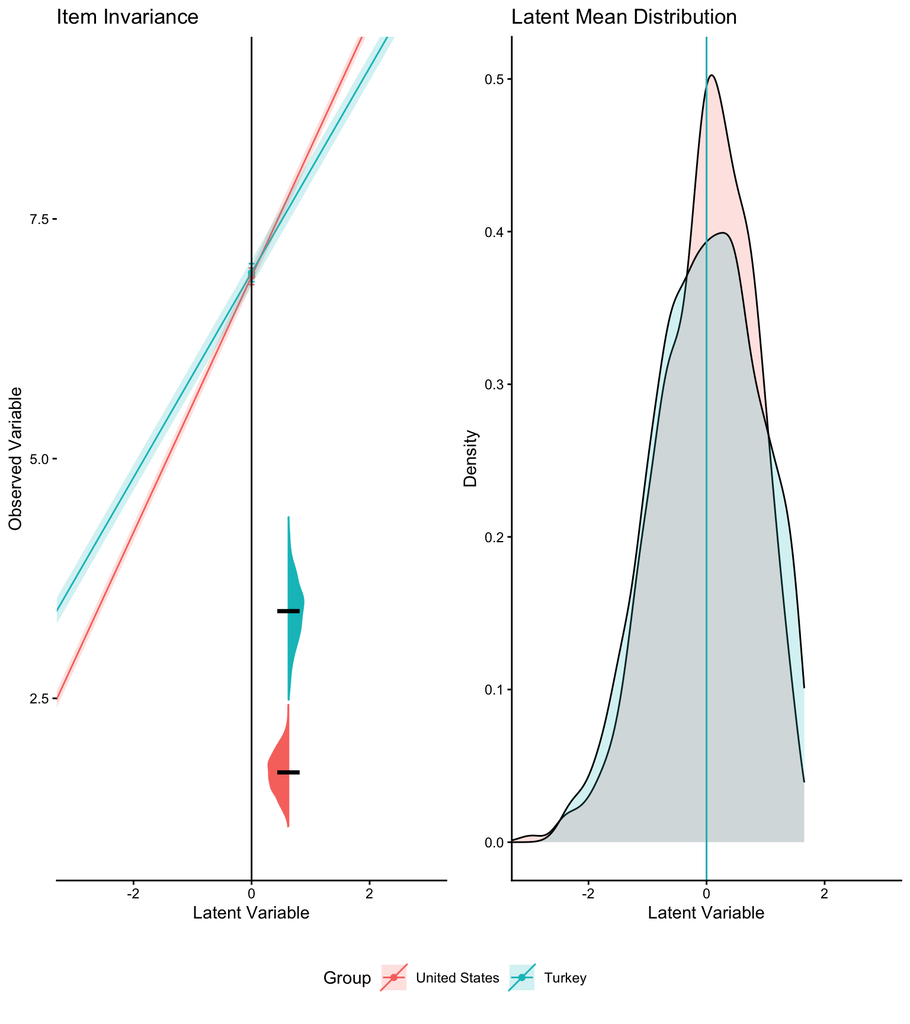

```r
plot_ic <- function(item, lv, step, fit) {
  plot_mi(data_coef = mg_IC$model_coef, model_step = step, item_name = item,
          x_limits = c(-3, 3), y_limits = range(d[[item]], na.rm = TRUE),
          conf.level = .95, model_results = fit, lv_name = lv)$complete
}
plot_ic("IC_1", "HI", "Configural", mg_IC$model_configural)
```

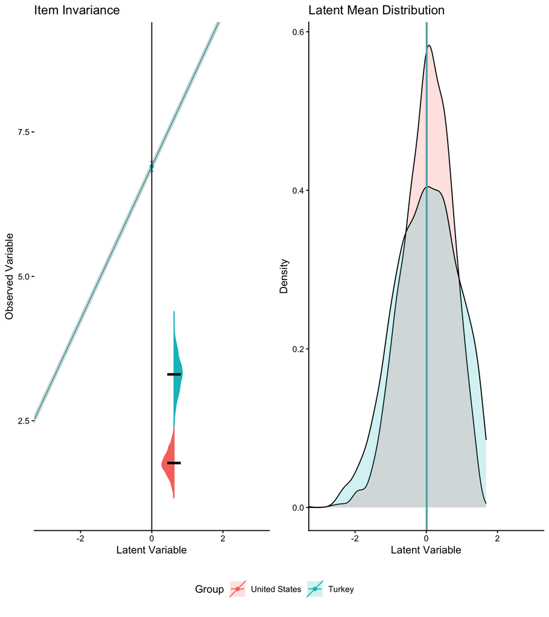

```r
plot_ic("IC_1", "HI", "intercepts", mg_IC$invariance_models$model.intercepts)
```

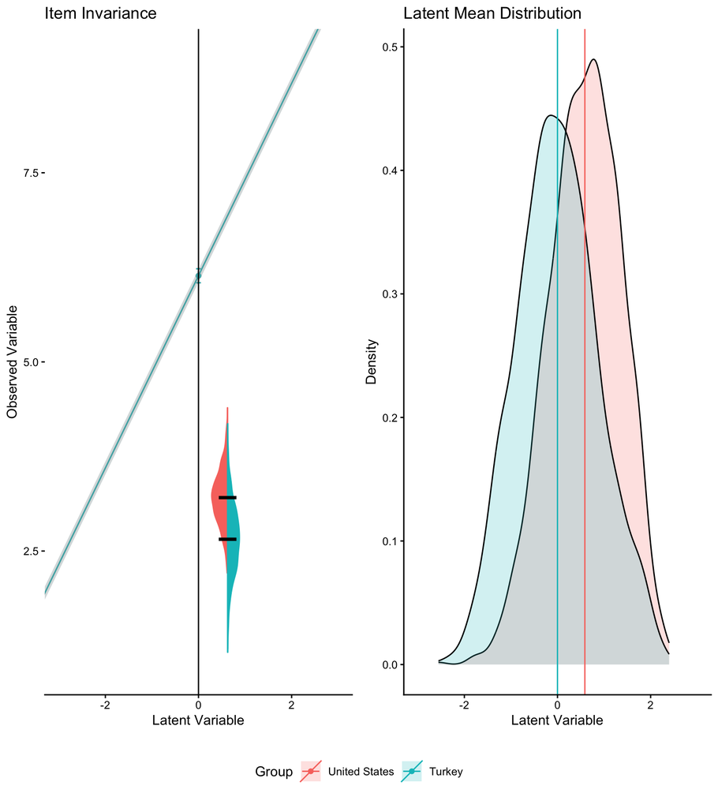

```r
# one item per subscale, scalar model
plot_ic("IC_5",  "VI", "intercepts", mg_IC$invariance_models$model.intercepts)
```

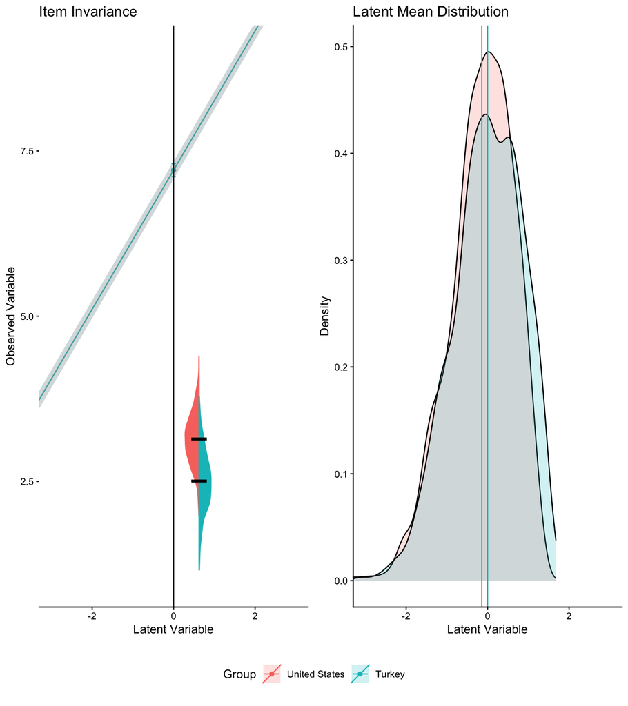

```r
plot_ic("IC_9",  "HC", "intercepts", mg_IC$invariance_models$model.intercepts)
```

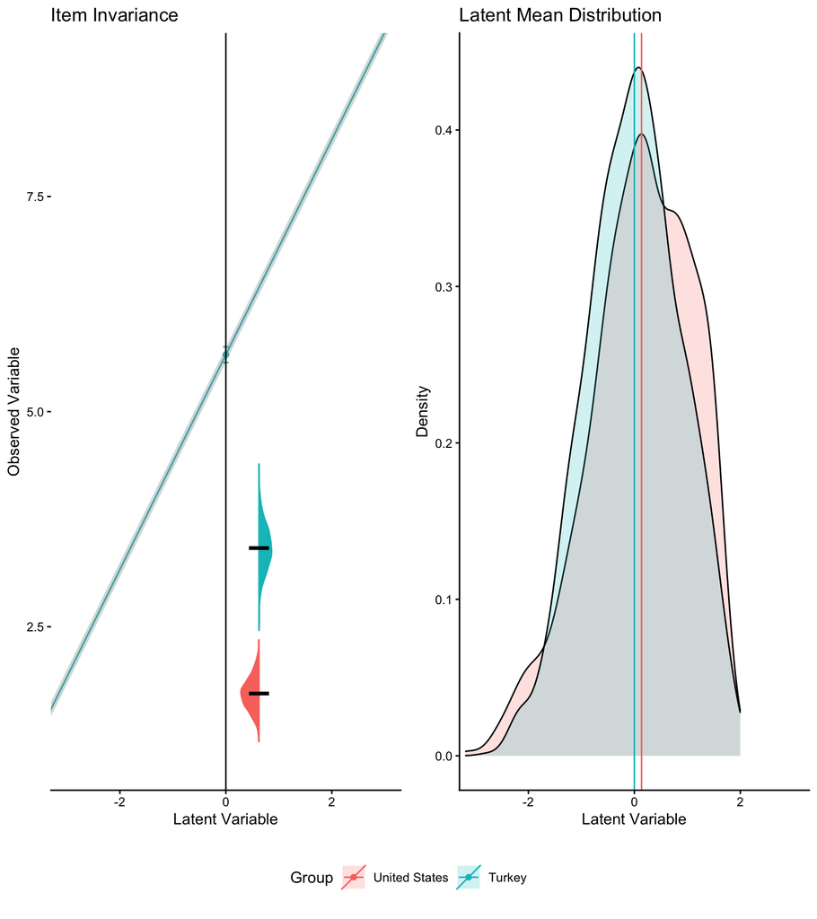

```r
plot_ic("IC_13", "VC", "intercepts", mg_IC$invariance_models$model.intercepts)
```

## `partial_mi()`: which loadings/intercepts drive non-invariance?

```r
dat_IC <- d %>% filter(Country %in% pairs$IC) %>% select(Country, all_of(IC_items)) %>% as.data.frame()
dat_IC$Country <- as.character(dat_IC$Country)
pmi_IC <- partial_mi(saved_model = mg_IC$invariance_models$model.loadings,
                     data = dat_IC, model = IC_model, group = "Country",
                     group.equal = "loadings", partial_step = "loadings",
                     estimator = "MLR", std.lv = TRUE)
knitr::kable(pmi_IC$fit_table, digits = 3)
```

| free.parameter | npar | fmin | chisq | df | pvalue | chisq.scaled | df.scaled | pvalue.scaled | chisq.scaling.factor | baseline.chisq | baseline.df | baseline.pvalue | baseline.chisq.scaled | baseline.df.scaled | baseline.pvalue.scaled | baseline.chisq.scaling.factor | cfi | tli | cfi.scaled | tli.scaled | cfi.robust | tli.robust | nnfi | rfi | nfi | pnfi | ifi | rni | nnfi.scaled | … |
| --- | --- | --- | --- | --- | --- | --- | --- | --- | --- | --- | --- | --- | --- | --- | --- | --- | --- | --- | --- | --- | --- | --- | --- | --- | --- | --- | --- | --- | --- | --- |
| HI =~ IC_1 | 97 | 0.3194115 | 1978.435 | 207 | 0 | 1700.492 | 207 | 0 | 1.163449 | 10285.55 | 240 | 0 | 8503.279 | 240 | 0 | 1.209598 | 0.8236597 | 0.7955474 | 0.8192616 | 0.7904482 | 0.8261572 | 0.7984431 | 0.7955474 | 0.7769844 | 0.8076490 | 0.6965973 | 0.8242370 | 0.8236597 | 0.7904482 | … |
| HI =~ IC_2 | 97 | 0.3135932 | 1942.397 | 207 | 0 | 1667.733 | 207 | 0 | 1.164693 | 10285.55 | 240 | 0 | 8503.279 | 240 | 0 | 1.209598 | 0.8272472 | 0.7997069 | 0.8232260 | 0.7950446 | 0.8297885 | 0.8026533 | 0.7997069 | 0.7810467 | 0.8111528 | 0.6996193 | 0.8278128 | 0.8272472 | 0.7950446 | … |
| HI =~ IC_3 | 97 | 0.3193695 | 1978.175 | 207 | 0 | 1697.971 | 207 | 0 | 1.165022 | 10285.55 | 240 | 0 | 8503.279 | 240 | 0 | 1.209598 | 0.8236856 | 0.7955775 | 0.8195666 | 0.7908019 | 0.8262158 | 0.7985111 | 0.7955775 | 0.7770137 | 0.8076743 | 0.6966191 | 0.8242629 | 0.8236856 | 0.7908019 | … |
| HI =~ IC_4 | 97 | 0.3067785 | 1900.186 | 207 | 0 | 1631.237 | 207 | 0 | 1.164875 | 10285.55 | 240 | 0 | 8503.279 | 240 | 0 | 1.209598 | 0.8314491 | 0.8045786 | 0.8276427 | 0.8001654 | 0.8340153 | 0.8075540 | 0.8045786 | 0.7858048 | 0.8152567 | 0.7031589 | 0.8320010 | 0.8314491 | 0.8001654 | … |
| VI =~ IC_5 | 97 | 0.3196812 | 1980.105 | 207 | 0 | 1699.380 | 207 | 0 | 1.165193 | 10285.55 | 240 | 0 | 8503.279 | 240 | 0 | 1.209598 | 0.8234934 | 0.7953547 | 0.8193962 | 0.7906043 | 0.8260262 | 0.7982912 | 0.7953547 | 0.7767961 | 0.8074866 | 0.6964572 | 0.8240713 | 0.8234934 | 0.7906043 | … |
| VI =~ IC_6 | 97 | 0.3192040 | 1977.149 | 207 | 0 | 1696.913 | 207 | 0 | 1.165145 | 10285.55 | 240 | 0 | 8503.279 | 240 | 0 | 1.209598 | 0.8237877 | 0.7956958 | 0.8196947 | 0.7909504 | 0.8263210 | 0.7986330 | 0.7956958 | 0.7771293 | 0.8077740 | 0.6967051 | 0.8243646 | 0.8237877 | 0.7909504 | … |
| VI =~ IC_7 | 97 | 0.3192248 | 1977.278 | 207 | 0 | 1696.245 | 207 | 0 | 1.165680 | 10285.55 | 240 | 0 | 8503.279 | 240 | 0 | 1.209598 | 0.8237748 | 0.7956809 | 0.8197756 | 0.7910442 | 0.8263191 | 0.7986309 | 0.7956809 | 0.7771147 | 0.8077615 | 0.6966943 | 0.8243518 | 0.8237748 | 0.7910442 | … |
| VI =~ IC_8 | 97 | 0.3191040 | 1976.530 | 207 | 0 | 1696.863 | 207 | 0 | 1.164814 | 10285.55 | 240 | 0 | 8503.279 | 240 | 0 | 1.209598 | 0.8238493 | 0.7957673 | 0.8197007 | 0.7909574 | 0.8263760 | 0.7986968 | 0.7957673 | 0.7771991 | 0.8078342 | 0.6967570 | 0.8244260 | 0.8238493 | 0.7909574 | … |
| HC =~ IC_9 | 97 | 0.3199115 | 1981.532 | 207 | 0 | 1702.721 | 207 | 0 | 1.163744 | 10285.55 | 240 | 0 | 8503.279 | 240 | 0 | 1.209598 | 0.8233514 | 0.7951900 | 0.8189918 | 0.7901355 | 0.8258535 | 0.7980910 | 0.7951900 | 0.7766353 | 0.8073479 | 0.6963376 | 0.8239298 | 0.8233514 | 0.7901355 | … |
| HC =~ IC_10 | 97 | 0.3189941 | 1975.849 | 207 | 0 | 1695.168 | 207 | 0 | 1.165577 | 10285.55 | 240 | 0 | 8503.279 | 240 | 0 | 1.209598 | 0.8239171 | 0.7958459 | 0.8199059 | 0.7911952 | 0.8264600 | 0.7987942 | 0.7958459 | 0.7772758 | 0.8079004 | 0.6968141 | 0.8244936 | 0.8239171 | 0.7911952 | … |
| HC =~ IC_11 | 97 | 0.3133836 | 1941.098 | 207 | 0 | 1666.151 | 207 | 0 | 1.165019 | 10285.55 | 240 | 0 | 8503.279 | 240 | 0 | 1.209598 | 0.8273765 | 0.7998568 | 0.8234175 | 0.7952666 | 0.8299252 | 0.8028119 | 0.7998568 | 0.7811931 | 0.8112791 | 0.6997282 | 0.8279417 | 0.8273765 | 0.7952666 | … |
| HC =~ IC_12 | 97 | 0.3198953 | 1981.431 | 207 | 0 | 1703.113 | 207 | 0 | 1.163417 | 10285.55 | 240 | 0 | 8503.279 | 240 | 0 | 1.209598 | 0.8233614 | 0.7952016 | 0.8189444 | 0.7900804 | 0.8258568 | 0.7980948 | 0.7952016 | 0.7766466 | 0.8073577 | 0.6963460 | 0.8239398 | 0.8233614 | 0.7900804 | … |
| VC =~ IC_13 | 97 | 0.3198296 | 1981.025 | 207 | 0 | 1699.323 | 207 | 0 | 1.165773 | 10285.55 | 240 | 0 | 8503.279 | 240 | 0 | 1.209598 | 0.8234019 | 0.7952486 | 0.8194030 | 0.7906122 | 0.8259462 | 0.7981985 | 0.7952486 | 0.7766925 | 0.8073973 | 0.6963801 | 0.8239801 | 0.8234019 | 0.7906122 | … |
| VC =~ IC_14 | 97 | 0.3177794 | 1968.326 | 207 | 0 | 1688.906 | 207 | 0 | 1.165444 | 10285.55 | 240 | 0 | 8503.279 | 240 | 0 | 1.209598 | 0.8246660 | 0.7967142 | 0.8206637 | 0.7920739 | 0.8272099 | 0.7996637 | 0.7967142 | 0.7781239 | 0.8086319 | 0.6974450 | 0.8252401 | 0.8246660 | 0.7920739 | … |
| VC =~ IC_15 | 97 | 0.3198482 | 1981.140 | 207 | 0 | 1698.810 | 207 | 0 | 1.166192 | 10285.55 | 240 | 0 | 8503.279 | 240 | 0 | 1.209598 | 0.8233904 | 0.7952353 | 0.8194651 | 0.7906841 | 0.8259434 | 0.7981953 | 0.7952353 | 0.7766795 | 0.8073860 | 0.6963705 | 0.8239687 | 0.8233904 | 0.7906841 | … |
| VC =~ IC_16 | 97 | 0.3166907 | 1961.582 | 207 | 0 | 1684.783 | 207 | 0 | 1.164294 | 10285.55 | 240 | 0 | 8503.279 | 240 | 0 | 1.209598 | 0.8253373 | 0.7974925 | 0.8211626 | 0.7926523 | 0.8278608 | 0.8004183 | 0.7974925 | 0.7788841 | 0.8092875 | 0.6980105 | 0.8259092 | 0.8253373 | 0.7926523 | … |